# Ecological state of macrozoobenthic communities - Burgas Bay

###### **Differences in assessment between stations**

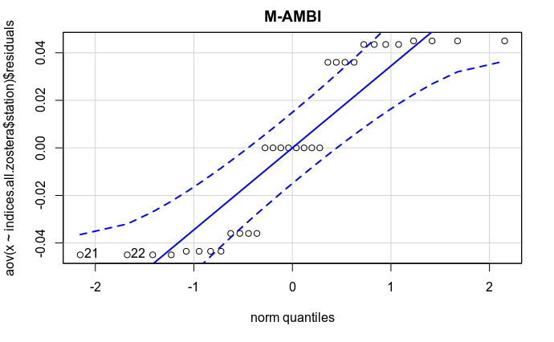

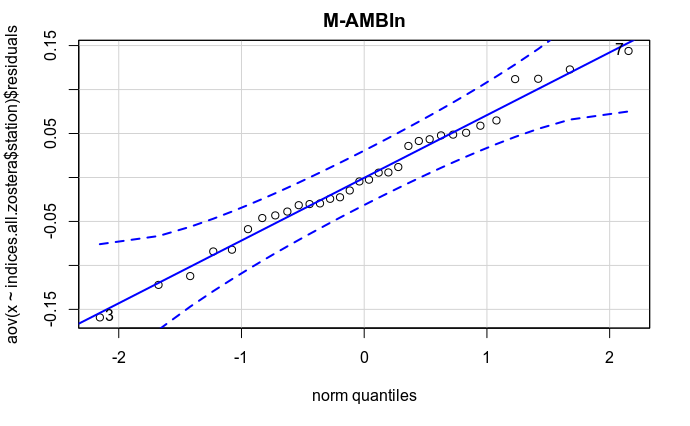

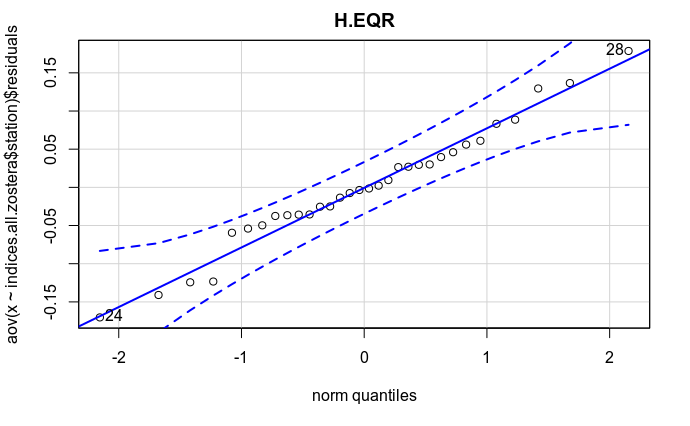

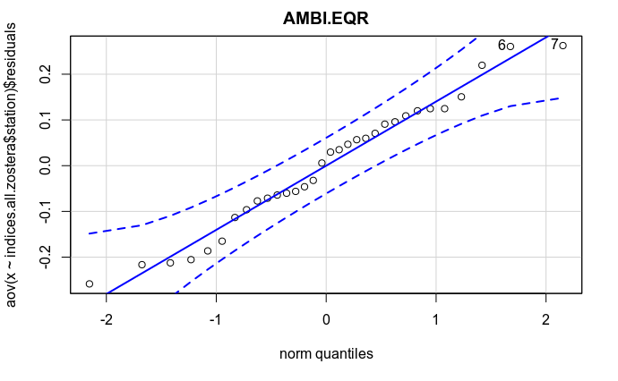

```
     M-AMBI M-AMBIn H.EQR AMBI.EQR BENTIX.EQR
[1,]     21       3    28        7         25
[2,]     22       7    24        6          6
```

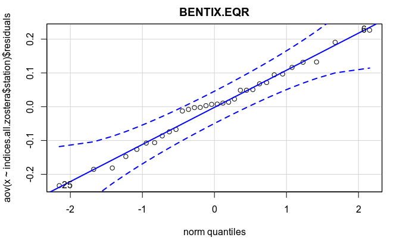

```r
mapply(function(x, y) car::qqPlot(aov(x ~ indices.all.zostera$station)$residuals, line = "robust", main = y),
       x = indices.all.zostera %>% select(`M-AMBI`, `M-AMBIn`, ends_with("EQR")),
       y = names(indices.all.zostera %>% select(`M-AMBI`, `M-AMBIn`, ends_with("EQR")))
       )
```

The worst offender is, actually, M-AMBI. Although the others are not faring much better. No clear idea what’s going on there.. Possibly, Poda and Otmanli, which are causing problems again with the differences between the 2 samplings.

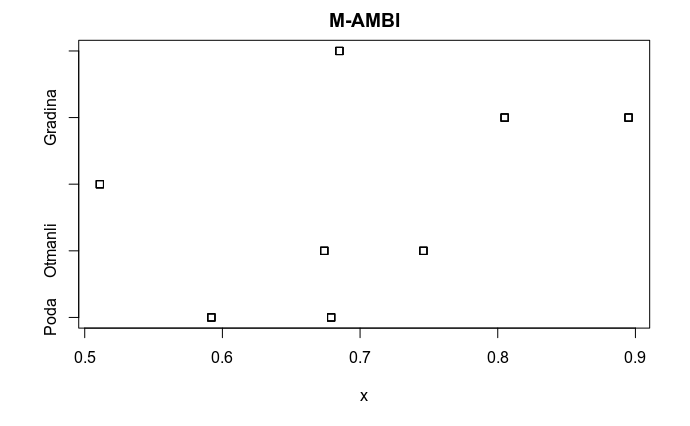

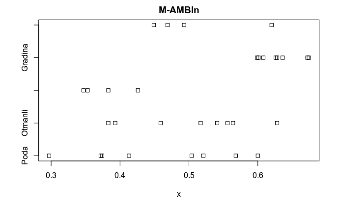

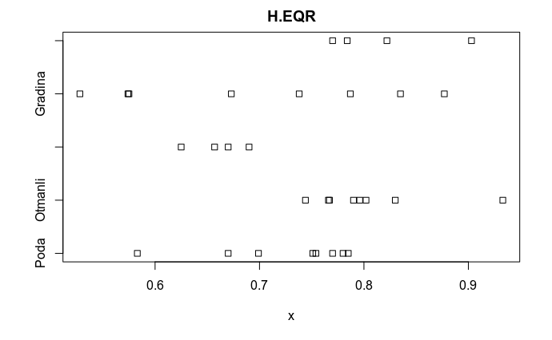

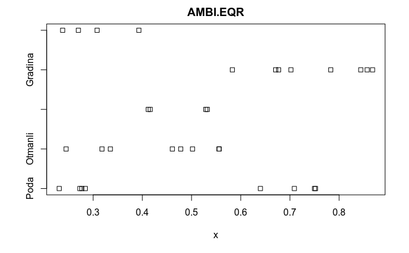

```
$`M-AMBI`
NULL

$`M-AMBIn`
NULL

$H.EQR
NULL

$AMBI.EQR
NULL

$BENTIX.EQR
NULL
```

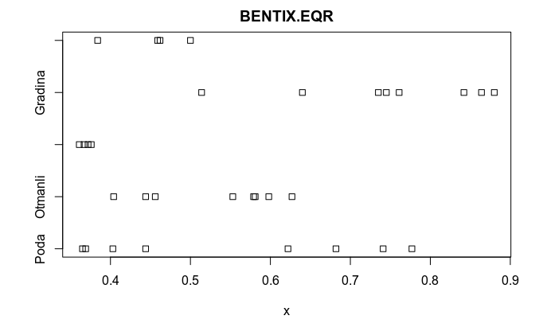

```r
mapply(function(x, y) stripchart(x ~ indices.all.zostera$station, main = y),
       x = indices.all.zostera %>% select(`M-AMBI`, `M-AMBIn`, ends_with("EQR")),
       y = names(indices.all.zostera %>% select(`M-AMBI`, `M-AMBIn`, ends_with("EQR")))
       )
```

I’m going again with robust regression, with station as factor.

```r
ind.rr.st.zostera <- apply(indices.all.zostera %>% dplyr::select(`M-AMBI`, `M-AMBIn`, ends_with("EQR")),
                           2,
                           function(x) MASS::rlm(x ~ station, data = indices.all.zostera)
                        )

lapply(ind.rr.st.zostera, summary)
```

```
$`M-AMBI`

Call: rlm(formula = x ~ station, data = indices.all.zostera)
Residuals:
       Min         1Q     Median         3Q        Max
-4.500e-02 -3.787e-02 -5.551e-17  3.788e-02  4.500e-02

Coefficients:
                Value   Std. Error t value
(Intercept)      0.6355  0.0139    45.7344
stationOtmanli   0.0745  0.0197     3.7911
stationVromos   -0.1245  0.0241    -5.1729
stationGradina   0.2145  0.0197    10.9154
stationRopotamo  0.0495  0.0241     2.0567

Residual standard error: 0.05893 on 27 degrees of freedom

$`M-AMBIn`

Call: rlm(formula = x ~ station, data = indices.all.zostera)
Residuals:
     Min       1Q   Median       3Q      Max
-0.15776 -0.03407 -0.00350  0.04711  0.14524

Coefficients:
                Value   Std. Error t value
(Intercept)      0.4548  0.0289    15.7410
stationOtmanli   0.0547  0.0409     1.3382
stationVromos   -0.0775  0.0500    -1.5490
stationGradina   0.1757  0.0409     4.3013
stationRopotamo  0.0455  0.0500     0.9094

Residual standard error: 0.06677 on 27 degrees of freedom

$H.EQR

Call: rlm(formula = x ~ station, data = indices.all.zostera)
Residuals:
      Min        1Q    Median        3Q       Max
-0.177475 -0.035191  0.003743  0.035187  0.171525
```

[output cut: 29 more lines]

```

Call: rlm(formula = x ~ station, data = indices.all.zostera)
Residuals:
     Min       1Q   Median       3Q      Max
-0.24454 -0.07725  0.00500  0.07168  0.23924

Coefficients:
                Value   Std. Error t value
(Intercept)      0.5378  0.0441    12.2013
stationOtmanli  -0.0075  0.0623    -0.1205
stationVromos   -0.1688  0.0763    -2.2107
stationGradina   0.2208  0.0623     3.5421
stationRopotamo -0.0865  0.0763    -1.1332

Residual standard error: 0.1169 on 27 degrees of freedom
```

Now we’ll do the appropriate post-hoc tests to see where the largest differences are.  
NB The seagrass data doesn’t want to play with my beautiful heteroscedastic variance estimator (could be because of the unequal sample sizes between groups?? works perfectly with the sand data), so I’m removing it.. No more time to play.

```r
ind.glht.st.zostera <- lapply(ind.rr.st.zostera,
                              function(x) multcomp::glht(x, mcp(station = "Tukey")))

mcp.st.labels.zostera <- lapply(ind.glht.st.zostera, multcomp::cld) # get some labels for the summary plots - significance of the comparisons

lapply(ind.glht.st.zostera, summary)
```

```
$`M-AMBI`

     Simultaneous Tests for General Linear Hypotheses

Multiple Comparisons of Means: Tukey Contrasts


Fit: rlm(formula = x ~ station, data = indices.all.zostera)

Linear Hypotheses:
                        Estimate Std. Error z value Pr(>|z|)
Otmanli - Poda == 0      0.07450    0.01965   3.791  0.00143 **
Vromos - Poda == 0      -0.12450    0.02407  -5.173  < 0.001 ***
Gradina - Poda == 0      0.21450    0.01965  10.915  < 0.001 ***
Ropotamo - Poda == 0     0.04950    0.02407   2.057  0.23575
Vromos - Otmanli == 0   -0.19900    0.02407  -8.268  < 0.001 ***
Gradina - Otmanli == 0   0.14000    0.01965   7.124  < 0.001 ***
Ropotamo - Otmanli == 0 -0.02500    0.02407  -1.039  0.83502
Gradina - Vromos == 0    0.33900    0.02407  14.085  < 0.001 ***
Ropotamo - Vromos == 0   0.17400    0.02779   6.261  < 0.001 ***
Ropotamo - Gradina == 0 -0.16500    0.02407  -6.856  < 0.001 ***
---
Signif. codes:  0 ‘***’ 0.001 ‘**’ 0.01 ‘*’ 0.05 ‘.’ 0.1 ‘ ’ 1
(Adjusted p values reported -- single-step method)


$`M-AMBIn`

     Simultaneous Tests for General Linear Hypotheses

Multiple Comparisons of Means: Tukey Contrasts


Fit: rlm(formula = x ~ station, data = indices.all.zostera)

Linear Hypotheses:
                         Estimate Std. Error z value Pr(>|z|)
Otmanli - Poda == 0      0.054675   0.040857   1.338   0.6634
Vromos - Poda == 0      -0.077512   0.050039  -1.549   0.5260
Gradina - Poda == 0      0.175738   0.040857   4.301   <0.001 ***
```

[output cut: 73 more lines]

```
Linear Hypotheses:
                         Estimate Std. Error z value Pr(>|z|)
Otmanli - Poda == 0     -0.007509   0.062330  -0.120  0.99995
Vromos - Poda == 0      -0.168759   0.076338  -2.211  0.17277
Gradina - Poda == 0      0.220777   0.062330   3.542  0.00343 **
Ropotamo - Poda == 0    -0.086509   0.076338  -1.133  0.78604
Vromos - Otmanli == 0   -0.161250   0.076338  -2.112  0.21132
Gradina - Otmanli == 0   0.228286   0.062330   3.663  0.00244 **
Ropotamo - Otmanli == 0 -0.079000   0.076338  -1.035  0.83688
Gradina - Vromos == 0    0.389536   0.076338   5.103  < 0.001 ***
Ropotamo - Vromos == 0   0.082250   0.088148   0.933  0.88233
Ropotamo - Gradina == 0 -0.307286   0.076338  -4.025  < 0.001 ***
---
Signif. codes:  0 ‘***’ 0.001 ‘**’ 0.01 ‘*’ 0.05 ‘.’ 0.1 ‘ ’ 1
(Adjusted p values reported -- single-step method)
```

Ok, now we know there are **significant differences** in index assessments between stations (+ between which pairs). Let’s plot them, using the summary tables we did before (mean + sd):

```r
## reshape the index summary tibble - long
ind.st.summary.zostera.long <- ind.st.summary.zostera %>%
    gather(key = ind, value = ind_value, -station) %>%
    ## separate the index column into 2: index and variable (mean or sd)
    separate(ind, into = c("index", "var"), sep = "_") %>%
    spread(var, ind_value)

## get rid of the "EQR" at the end of the index names
ind.st.summary.zostera.long <- ind.st.summary.zostera.long %>%
  mutate(index = gsub(index, pattern = ".EQR", replacement = ""))

## replace H with H' and convert index to factor (to have them in the desired order)
(ind.st.summary.zostera.long <- ind.st.summary.zostera.long %>%
    mutate(index = gsub(index, pattern = "H", replacement = "H'")) %>%
    mutate(index = factor(index, levels = c("AMBI", "BENTIX", "H'", "M-AMBI", "M-AMBIn")))
)
```

| station | index | mean | sd |
| --- | --- | --- | --- |
| Poda | AMBI | 0.489500 | 0.241624857 |
| Poda | BENTIX | 0.550375 | 0.173389683 |
| Poda | H' | 0.724000 | 0.069717799 |
| Poda | M-AMBI | 0.635500 | 0.046503456 |
| Poda | M-AMBIn | 0.456125 | 0.107383741 |
| Otmanli | AMBI | 0.431375 | 0.117095733 |
| Otmanli | BENTIX | 0.530250 | 0.083076127 |
| Otmanli | H' | 0.803500 | 0.058544245 |
| Otmanli | M-AMBI | 0.710000 | 0.038485619 |
| Otmanli | M-AMBIn | 0.505125 | 0.086350511 |

[output cut: 15 more lines]

We need to get and add the significance labels (will make life immensely easier if they are in the same tibble).

```r
## extract the significance letter labels that we generated before. Don't ask how I came to this - I remember digging relentlessly through blogs and forums, and nearly going crazy with it..
ind.st.labels.zostera <- plyr::ldply(mcp.st.labels.zostera, function(x) x[[10]][[1]])

## fix index names
ind.st.labels.zostera$.id <- recode(ind.st.labels.zostera$.id,
                                 "H.EQR" = "H'", "AMBI.EQR" = "AMBI", "M-AMBI" = "M-AMBI", "BENTIX.EQR" = "BENTIX", "M-AMBIn" = "M-AMBIn")

ind.st.labels.zostera$.id <- factor(ind.st.labels.zostera$.id, levels = c("AMBI", "BENTIX", "H'", "M-AMBI", "M-AMBIn"))

ind.st.labels.zostera
```

| .id | Poda | Otmanli | Vromos | Gradina | Ropotamo |
| --- | --- | --- | --- | --- | --- |
| M-AMBI | b | c | a | d | bc |
| M-AMBIn | a | a | a | b | ab |
| H' | ab | b | a | ab | b |
| AMBI | a | a | a | b | a |
| BENTIX | a | a | a | b | a |

```r
## convert to long, rename the index column & make station a factor
ind.st.labels.zostera.long <- ind.st.labels.zostera %>%
    gather(key = station, value = label, -.id) %>%
    rename(index = .id) %>%
    mutate(station = factor(station, levels = levels(indices.all.zostera$station)))

## add to the dataset for plotting
(ind.st.summary.zostera.long <- left_join(ind.st.summary.zostera.long,
                                       ind.st.labels.zostera.long,
                                       by = c("station", "index"))
)
```

| station | index | mean | sd | label |
| --- | --- | --- | --- | --- |
| Poda | AMBI | 0.489500 | 0.241624857 | a |
| Poda | BENTIX | 0.550375 | 0.173389683 | a |
| Poda | H' | 0.724000 | 0.069717799 | ab |
| Poda | M-AMBI | 0.635500 | 0.046503456 | b |
| Poda | M-AMBIn | 0.456125 | 0.107383741 | a |
| Otmanli | AMBI | 0.431375 | 0.117095733 | a |
| Otmanli | BENTIX | 0.530250 | 0.083076127 | a |
| Otmanli | H' | 0.803500 | 0.058544245 | b |
| Otmanli | M-AMBI | 0.710000 | 0.038485619 | c |
| Otmanli | M-AMBIn | 0.505125 | 0.086350511 | a |

[output cut: 15 more lines]

The ecological class limits for the summary plots are the same as for the sand stations - will be recycled.

Plot the comparison of the indices by station.

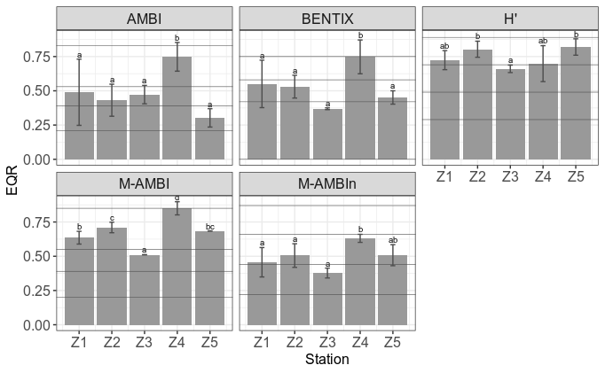

```r
plot.ind.st.summary.zostera <- ggplot(ind.st.summary.zostera.long,
                                   aes(x = as.numeric(station), y = mean)) +
  geom_bar(position = position_dodge(), stat = "identity", fill = "grey60") +
  ## error bars = sd
  geom_errorbar(aes(ymin = mean - sd, ymax = mean + sd),
                width = 0.15, colour = "grey30", position = position_dodge(0.9)) +
  ## labels - significant difference pairs (above error bars)
  geom_text(aes(x = as.numeric(station), y = mean + sd, label = label), vjust = -0.3, size = 2.5) +
  labs(x = "Station", y = "EQR") +
  facet_wrap(~index) +
  scale_y_continuous(breaks = seq(0, 1, 0.25)) +
  scale_x_continuous(breaks = 1:5, labels = paste0("Z", unique(as.numeric(ind.st.summary.zostera.long$station)))) +
  text_size(text.x = 12, text.y = 12, title.x = 12, title.y = 12, strip.x = 12)

## add the limits of the ecological classes for each index
## NB names of indices (facets) have to match in order for the lines to go where they should (otherwise they'll go in separate, additional facets)!
(plot.ind.st.summary.zostera <- plot.ind.st.summary.zostera +
    geom_hline(data = ind.limits.long, aes(yintercept = limits), lwd = 0.2, colour = "grey30")
)
```

Well isn’t this a fine mess..  
AMBI and BENTIX think that Z1-Z3 and Z5 are more or less the same, and Z4 is much better - kinda logical and consistent.  
There aren’t too many differences between stations with H - and it also gives pretty high ES to all.  
M-AMBI also thinks that Z4-Gradina is in the best ES, and the rest are not too bad either. M-AMBIn, on the other hand, gives moderate to all stations, and even poor to one (Z3). Nice job, unadjusted limits!

Save the station summary plot.

```r
ggsave(here(figures.dir, "ind_station_summary_zostera.png"),
       plot.ind.st.summary.zostera,
       dpi = 300, width = 17, height = 15, units = "cm")
```

Redo this plot with EC as strips of colour in the background.

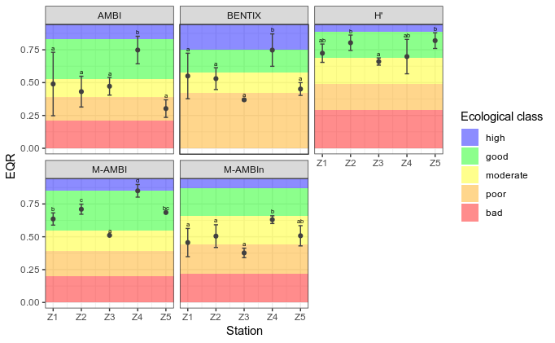

```r
(plot.ind.st.summary.strips.zostera <- ggplot(ind.st.summary.zostera.long,
                                              aes(x = as.numeric(station), y = mean)) +
   ## add the strips first - so as to form the background, not overlap the points
   geom_rect(data = ind.limits.strips.long,
             aes(xmin = -Inf, xmax = Inf, ymin = ymin, ymax = ymax, fill = class),
             alpha = 0.45, inherit.aes = FALSE) +
   scale_fill_manual(name = "Ecological class", values = es.classes) +

   ## error bars = sd. Plot first, so as to go behind the dots
   geom_errorbar(aes(ymin = mean - sd, ymax = mean + sd),
                 width = 0.15, colour = "grey25", position = position_dodge(0.9)) +
   geom_point(colour = "grey25") +
   ## labels - significant difference pairs (above error bars)
   geom_text(aes(x = as.numeric(station), y = mean + sd, label = label), vjust = -0.5, size = 2) +
   labs(x = "Station", y = "EQR") +
   facet_wrap(~index) +
   scale_y_continuous(breaks = seq(0, 1, 0.25)) +
   scale_x_continuous(breaks = 1:5, labels = paste0("Z", unique(as.numeric(ind.st.summary.zostera.long$station))))
)
```

Save this.

```r
ggsave(here(figures.dir, "ind_station_summary_strips_zostera.png"),
       plot.ind.st.summary.strips.zostera,
       dpi = 300, width = 17, height = 15, units = "cm")
```

##### Index performance vs environmental parameters

###### **Normalize indices (MEDGIG)**

Normalize the index EQRs.

```r
## uses my custom function for the normalization
(indices.all.norm.zostera <- as_tibble(mapply(normalize_index,
                                              indices.all.zostera %>% dplyr::select(`M-AMBI`, `M-AMBIn`, ends_with("EQR")) %>% dplyr::select(H.EQR, AMBI.EQR, `M-AMBI`, BENTIX.EQR, `M-AMBIn`),
                                              ind.limits,
                                              SIMPLIFY = FALSE))
)
```

| H.EQR | AMBI.EQR | M-AMBI | BENTIX.EQR | M-AMBIn |
| --- | --- | --- | --- | --- |
| 0.6610000 | 0.2233333 | 0.6280000 | 0.3738095 | 0.3400000 |
| 0.6950000 | 0.2744444 | 0.6280000 | 0.4300000 | 0.3754545 |
| 0.5800000 | 0.2700000 | 0.6280000 | 0.3757143 | 0.2700000 |
| 0.6640000 | 0.2822222 | 0.6280000 | 0.3919048 | 0.3381818 |
| 0.6900000 | 0.6733333 | 0.6860000 | 0.6494118 | 0.4736364 |
| 0.4930000 | 0.7466667 | 0.6860000 | 0.8216000 | 0.4581818 |
| 0.6090000 | 0.7480000 | 0.6860000 | 0.7894118 | 0.5454545 |
| 0.6800000 | 0.7193333 | 0.6860000 | 0.7200000 | 0.5163636 |
| 0.7120000 | 0.3200000 | 0.6826667 | 0.4450000 | 0.3481818 |
| 0.6770000 | 0.3388889 | 0.6826667 | 0.4300000 | 0.4172727 |

[output cut: 22 more lines]

###### **Correlation with environmental parameters**

Import environmental data for seagrass.  
Again, as before, I’ll use the most significant ones determined by PCA: LUSI, chl-a, Ntot, secchi + all sediment parameters (except the most inter-correlated): TOM, moisture content, mean grain size, sand, silt_clay + all seagrass parameters: shoot count, above-ground biomass, below-ground biomass.  
Import the environmental parameters (from the cleaned files; see multivariate analyses notebook).

```r
(env.data.zostera <- read_csv(here(save.dir, "env_data_ordinations_zostera.csv"))
)
```

| station | year | Ntotal | chl_a | secchi | LUSI | TOM | moisture_content | mean_grain_size | sand | silt_clay | shoot_count | ag_biomass_wet | bg_biomass_wet |
| --- | --- | --- | --- | --- | --- | --- | --- | --- | --- | --- | --- | --- | --- |
| Poda | 2013 | 22.46 | 4.47 | 3.00 | 6.25 | 2.089447 | 27.09861 | 73.81561 | 87.20685 | 11.2322516 | 2092.426 | 773.5302 | 202.1566 |
| Poda | 2013 | 22.46 | 4.47 | 3.00 | 6.25 | 2.089447 | 27.09861 | 73.81561 | 87.20685 | 11.2322516 | 2092.426 | 773.5302 | 202.1566 |
| Poda | 2013 | 22.46 | 4.47 | 3.00 | 6.25 | 2.089447 | 27.09861 | 73.81561 | 87.20685 | 11.2322516 | 2092.426 | 773.5302 | 202.1566 |
| Poda | 2013 | 22.46 | 4.47 | 3.00 | 6.25 | 2.089447 | 27.09861 | 73.81561 | 87.20685 | 11.2322516 | 2092.426 | 773.5302 | 202.1566 |
| Poda | 2014 | 22.46 | 4.47 | 3.00 | 6.25 | 2.037798 | 25.73742 | 74.28578 | 89.27877 | 8.7145821 | 1838.254 | 639.1014 | 236.6624 |
| Poda | 2014 | 22.46 | 4.47 | 3.00 | 6.25 | 2.037798 | 25.73742 | 74.28578 | 89.27877 | 8.7145821 | 1838.254 | 639.1014 | 236.6624 |
| Poda | 2014 | 22.46 | 4.47 | 3.00 | 6.25 | 2.037798 | 25.73742 | 74.28578 | 89.27877 | 8.7145821 | 1838.254 | 639.1014 | 236.6624 |
| Poda | 2014 | 22.46 | 4.47 | 3.00 | 6.25 | 2.037798 | 25.73742 | 74.28578 | 89.27877 | 8.7145821 | 1838.254 | 639.1014 | 236.6624 |
| Otmanli | 2013 | 20.08 | 3.67 | 4.25 | 6.25 | 2.154777 | 30.81230 | 73.54107 | 84.97093 | 12.0718771 | 2012.837 | 469.6277 | 658.3825 |
| Otmanli | 2013 | 20.08 | 3.67 | 4.25 | 6.25 | 2.154777 | 30.81230 | 73.54107 | 84.97093 | 12.0718771 | 2012.837 | 469.6277 | 658.3825 |

[output cut: 22 more lines]

Calculate the correlations..

```r
ind.corr.env.zostera <- Hmisc::rcorr(as.matrix(bind_cols(indices.all.norm.zostera, S = indices.all.zostera$S)), # also include S - as suggested by article review
                                     as.matrix(env.data.zostera %>% dplyr::select(-c(station, year))),
                                     type = "spearman")


corstars(ind.corr.env.zostera)
```

|  | H.EQR | AMBI.EQR | M-AMBI | BENTIX.EQR | M-AMBIn | S | Ntotal | chl_a | secchi | LUSI | TOM | moisture_content | mean_grain_size | sand | silt_clay | shoot_count | ag_biomass_wet |
| --- | --- | --- | --- | --- | --- | --- | --- | --- | --- | --- | --- | --- | --- | --- | --- | --- | --- |
| H.EQR |  |  |  |  |  |  |  |  |  |  |  |  |  |  |  |  |  |
| AMBI.EQR | -0.38* |  |  |  |  |  |  |  |  |  |  |  |  |  |  |  |  |
| M-AMBI | 0.14 | 0.59*** |  |  |  |  |  |  |  |  |  |  |  |  |  |  |  |
| BENTIX.EQR | -0.15 | 0.85*** | 0.79*** |  |  |  |  |  |  |  |  |  |  |  |  |  |  |
| M-AMBIn | 0.19 | 0.7*** | 0.82*** | 0.83*** |  |  |  |  |  |  |  |  |  |  |  |  |  |
| S | 0.25 | 0.11 | 0.65*** | 0.44* | 0.66*** |  |  |  |  |  |  |  |  |  |  |  |  |
| Ntotal | 0.37* | -0.46** | -0.1 | -0.08 | -0.15 | 0.19 |  |  |  |  |  |  |  |  |  |  |  |
| chl_a | 0.29 | -0.61*** | -0.41* | -0.36* | -0.42* | -0.04 | 0.93*** |  |  |  |  |  |  |  |  |  |  |
| secchi | 0.21 | 0.09 | 0.66*** | 0.18 | 0.45* | 0.8*** | -0.21 | -0.21 |  |  |  |  |  |  |  |  |  |
| LUSI | 0.02 | -0.14 | -0.46** | -0.16 | -0.36* | -0.57*** | 0.14 | 0.22 | -0.92*** |  |  |  |  |  |  |  |  |

[output cut: 8 more lines]

```r
## kable(corstars(ind.corr.env.zostera)) # better-looking table
```

Last-last thing to try: given the environmental parameters, check if the classification system successfully differentiates between between classes, and between which subsequent classes - best?  
I’m only going to use the environmental parameters with which the indices have the best correlations (yes, I know it is highly subjective, and I don’t care).  
Gather the needed data (yes, I’m making another two-three-million useless temporary data frames).

```r
## get the index EQRs, and convert to qualitative. MAKE EXTRA SURE THE COLUMNS ARE IN THE SAME ORDER IN THE TWO DFS, OTHERWISE THE WRONG LIMITS WILL BE APPLIED TO EACH INDEX
(ind.qual.zostera <- map2_df(indices.all.norm.zostera %>% select(H.EQR, AMBI.EQR, `M-AMBI`, BENTIX.EQR, `M-AMBIn`),
                             ind.limits,
                             ~es_qualitative(.x, .y)
                             )
)
```

| H.EQR | AMBI.EQR | M-AMBI | BENTIX.EQR | M-AMBIn |
| --- | --- | --- | --- | --- |
| moderate | poor | good | poor | poor |
| good | poor | good | moderate | poor |
| moderate | poor | good | poor | poor |
| moderate | poor | good | poor | poor |
| good | good | good | good | moderate |
| moderate | good | good | high | moderate |
| moderate | good | good | high | moderate |
| moderate | good | good | good | moderate |
| good | poor | good | moderate | poor |
| moderate | poor | good | moderate | poor |

[output cut: 22 more lines]

```r
## get (manually) the environmental parameters, and add to the qualitative index df. AGAIN MAKE SURE THE ROWS ARE IN THE SAME ORDER (I TRUST THEY ARE HERE, BUT IN FUTURE)
(ind.qual.env.zostera <- bind_cols(ind.qual.zostera,
                                   env.data.zostera %>% select(TOM, chl_a, secchi, LUSI, shoot_count))
)
```

| H.EQR | AMBI.EQR | M-AMBI | BENTIX.EQR | M-AMBIn | TOM | chl_a | secchi | LUSI | shoot_count |
| --- | --- | --- | --- | --- | --- | --- | --- | --- | --- |
| moderate | poor | good | poor | poor | 2.089447 | 4.47 | 3.00 | 6.25 | 2092.426 |
| good | poor | good | moderate | poor | 2.089447 | 4.47 | 3.00 | 6.25 | 2092.426 |
| moderate | poor | good | poor | poor | 2.089447 | 4.47 | 3.00 | 6.25 | 2092.426 |
| moderate | poor | good | poor | poor | 2.089447 | 4.47 | 3.00 | 6.25 | 2092.426 |
| good | good | good | good | moderate | 2.037798 | 4.47 | 3.00 | 6.25 | 1838.254 |
| moderate | good | good | high | moderate | 2.037798 | 4.47 | 3.00 | 6.25 | 1838.254 |
| moderate | good | good | high | moderate | 2.037798 | 4.47 | 3.00 | 6.25 | 1838.254 |
| moderate | good | good | good | moderate | 2.037798 | 4.47 | 3.00 | 6.25 | 1838.254 |
| good | poor | good | moderate | poor | 2.154777 | 3.67 | 4.25 | 6.25 | 2012.837 |
| moderate | poor | good | moderate | poor | 2.154777 | 3.67 | 4.25 | 6.25 | 2012.837 |

[output cut: 22 more lines]

```r
## convert to long, key = index
(ind.qual.env.long.zostera <- gather(ind.qual.env.zostera, key = "index", value = "assessment", -c(TOM:shoot_count)) %>%
    ## convert the qualitative assessments to factor, so that the classes go high to bad
    mutate(assessment = factor(assessment, levels = c("high", "good", "moderate", "poor", "bad")))
)
```

| TOM | chl_a | secchi | LUSI | shoot_count | index | assessment |
| --- | --- | --- | --- | --- | --- | --- |
| 2.089447 | 4.47 | 3.00 | 6.25 | 2092.426 | H.EQR | moderate |
| 2.089447 | 4.47 | 3.00 | 6.25 | 2092.426 | H.EQR | good |
| 2.089447 | 4.47 | 3.00 | 6.25 | 2092.426 | H.EQR | moderate |
| 2.089447 | 4.47 | 3.00 | 6.25 | 2092.426 | H.EQR | moderate |
| 2.037798 | 4.47 | 3.00 | 6.25 | 1838.254 | H.EQR | good |
| 2.037798 | 4.47 | 3.00 | 6.25 | 1838.254 | H.EQR | moderate |
| 2.037798 | 4.47 | 3.00 | 6.25 | 1838.254 | H.EQR | moderate |
| 2.037798 | 4.47 | 3.00 | 6.25 | 1838.254 | H.EQR | moderate |
| 2.154777 | 3.67 | 4.25 | 6.25 | 2012.837 | H.EQR | good |
| 2.154777 | 3.67 | 4.25 | 6.25 | 2012.837 | H.EQR | moderate |

[output cut: 150 more lines]

Make a boxplot of the distribution of classes vs the environmental parameters for each index.

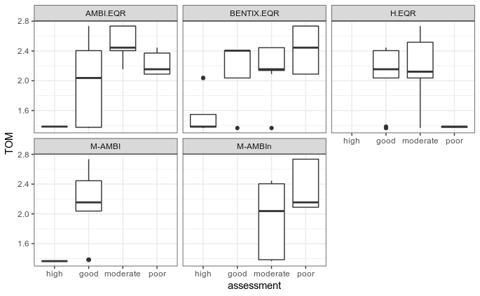

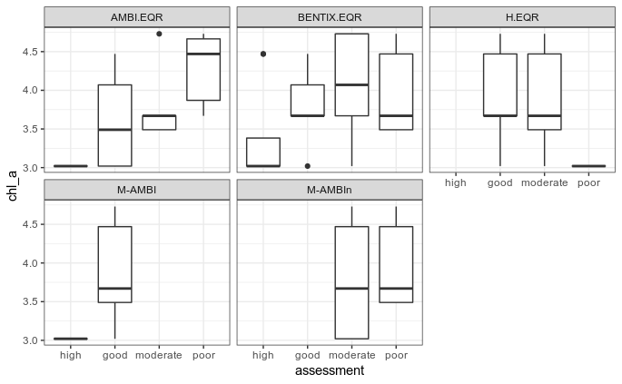

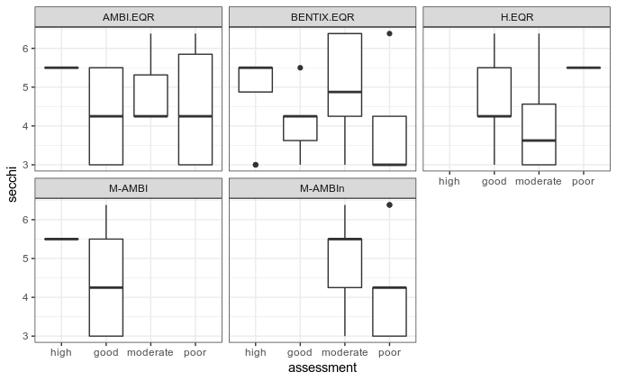

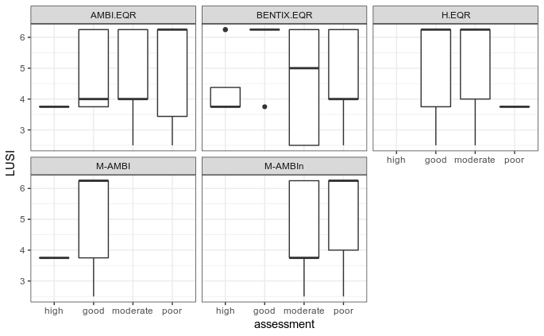

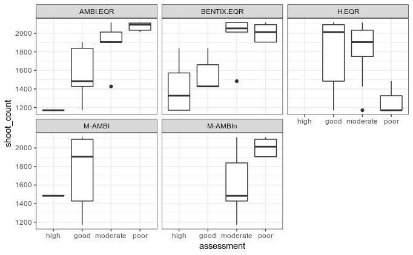

```r
## to avoid repeating code for each variable, AND to have nice y-axis labels..
map2(ind.qual.env.long.zostera %>% select(TOM:shoot_count),
     names(ind.qual.env.long.zostera %>% select(TOM:shoot_count)),
     ~ggplot(ind.qual.env.long.zostera, aes(x = assessment, y = .x)) +
       geom_boxplot() +
       labs(y = .y) +
       facet_wrap(~index))
```

###### **Index agreement analyses**

Calculate the absolute average class difference between indices.

```r
## calculate the absolute class difference - NB this is NOT the average - will have to be calculated later. Uses custom function
(ind.abs.class.diff.zostera <- ind_abs_diff(indices.all.norm.zostera, nb.classes = 5))
```

```
    H.EQR-AMBI.EQR H.EQR-M-AMBI H.EQR-BENTIX.EQR H.EQR-M-AMBIn AMBI.EQR-M-AMBI
V1               2            0                2             2               2
V2               2            0                1             2               2
V3               1            1                1             1               2
V4               2            0                2             2               2
V5               0            0                0             1               0
V6               1            1                2             0               0
V7               0            0                0             1               0
V8               0            0                0             1               0
V9               2            0                1             2               2
V10              2            0                1             1               2
V11              2            1                2             2               1
V12              2            0                2             2               2
V13              1            0                1             1               1
V14              0            0                0             1               0
V15              0            0                0             1               0
V16              1            0                0             1               1
V17              0            0                1             1               0
V18              1            0                1             1               1
V19              0            0                1             1               0
V20              1            1                2             2               0
V21              1            1                1             0               0
V22              2            1                2             0               1
V23              0            0                0             1               0
V24              2            1                2             0               1
V25              0            1                1             1               1
V26              0            1                1             0               1
V27              2            2                2             0               0
V28              0            1                0             0               1
V29              2            0                2             1               2
V30              2            0                1             1               2
V31              2            0                1             1               2
V32              2            1                2             2               1
    AMBI.EQR-BENTIX.EQR AMBI.EQR-M-AMBIn M-AMBI-BENTIX.EQR M-AMBI-M-AMBIn
V1                    0                0                 2              2
V2                    1                0                 1              2
V3                    0                0                 2              2
V4                    0                0                 2              2
V5                    0                1                 0              1
V6                    1                1                 1              1
```

[output cut: 44 more lines]

```
V18                  0
V19                  0
V20                  0
V21                  1
V22                  2
V23                  1
V24                  2
V25                  0
V26                  1
V27                  2
V28                  0
V29                  1
V30                  0
V31                  0
V32                  0
```

Curiously, there don’t seem to be more than 2 classes difference.. I suppose that’s ok..

```r
## calculate the average class difference, and prepare data for plotting
ind.abs.av.class.diff.zostera <- bind_rows(colMeans(ind.abs.class.diff.zostera)) ## THIS actually calculates the average class difference - by column

## convert to long and prepare for plotting (fix names and labels,..)
ind.abs.av.class.diff.zostera.long <- ind.abs.av.class.diff.zostera %>%
  gather(key = ind, value = diff)

(ind.abs.av.class.diff.zostera.long <- ind.abs.av.class.diff.zostera.long %>%
    arrange(desc(diff)) %>%
    mutate(ind = gsub(".EQR", "", x = ind)) %>%
    mutate(ind = gsub("H", "H'", x = ind)) %>%
    mutate(ind = factor(ind, levels = ind)) ## this order is necessary, because I want indices on the y axis, and ggplot will plot them bottom to top, alphabetically, regardless of what I tell it
)
```

| ind | diff |
| --- | --- |
| M-AMBI-M-AMBIn | 1.25000 |
| H'-AMBI | 1.09375 |
| H'-BENTIX | 1.09375 |
| H'-M-AMBIn | 1.03125 |
| AMBI-M-AMBI | 0.93750 |
| M-AMBI-BENTIX | 0.87500 |
| AMBI-M-AMBIn | 0.75000 |
| BENTIX-M-AMBIn | 0.62500 |
| AMBI-BENTIX | 0.43750 |
| H'-M-AMBI | 0.40625 |

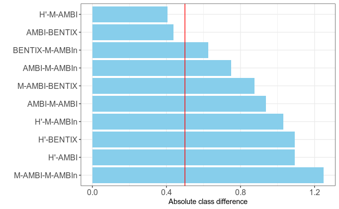

```r
(plot.ind.abs.av.class.diff.zostera <- ggplot(ind.abs.av.class.diff.zostera.long,
                                           aes(x = ind, y = diff)) +
    geom_bar(stat = "identity", fill = "sky blue") +
    geom_hline(yintercept = 0.5, col = "red") + # the acceptable difference limit according to the intercalibration
    coord_flip() +
    labs(x = "", y = "Absolute class difference") +
    text_size(text.x = 12, text.y = 12, title.y = 12)
)
```

This is interesting..  
The highest agreement is between H and M-AMBI, and AMBI and BENTIX - the only acceptable ones, really..  
Then, BENTIX and M-AMBIn - really?? And worse and worse from there, erratic, seems like. (Although, as an aside, the highest difference is still less than that observed for the sand stations)..  
I’m blaming this on the futility of using indices not adapted for this biotope and its particularities - see the unusually high proportions of EG5 and EG4, which are present even in supposedly good conditions (Z4). Unless something is done, these indices are probably not to be used for ES assessments of zoobenthos in seagrass.

Save the plot.

```r
ggsave(here(figures.dir, "ind_abs_class_diff_zostera.png"),
       plot.ind.abs.av.class.diff.zostera,
       dpi = 300, width = 16, height = 15, units = "cm")
```

Calculate the percentage agreement between indices.

```r
## summarize the calculated class differences (for 5 classes)
ind.percent.agreement.zostera <- as_tibble(ind.abs.class.diff.zostera) %>%
    gather(key = ind, value = diff) %>%
    ## recoding the class difference so that all differences of > 2 classes form a single group not necessary here - there are no > 2 classes differences
    # mutate(diff = recode(diff, "0" = 0, "1" = 1, "2" = 2, "3" = 3, "4" = 3)) %>%
    group_by(ind, diff) %>%
    summarize(count = n()) %>%
    ungroup()

## calculate the % agreement
ind.percent.agreement.zostera <- ind.percent.agreement.zostera %>%
  group_by(ind) %>%
  mutate(percent_agr = count/sum(count) * 100)

## fix names a bit (as before)
(ind.percent.agreement.zostera <- ind.percent.agreement.zostera %>%
    ungroup() %>%
    mutate(ind = gsub(".EQR", "", x = ind)) %>%
    mutate(ind = gsub("H", "H'", x = ind)) %>%
    arrange(diff, desc(percent_agr))
)
```

| ind | diff | count | percent_agr |
| --- | --- | --- | --- |
| H'-M-AMBI | 0 | 20 | 62.500 |
| AMBI-BENTIX | 0 | 19 | 59.375 |
| BENTIX-M-AMBIn | 0 | 16 | 50.000 |
| AMBI-M-AMBI | 0 | 12 | 37.500 |
| AMBI-M-AMBIn | 0 | 12 | 37.500 |
| H'-AMBI | 0 | 11 | 34.375 |
| M-AMBI-BENTIX | 0 | 10 | 31.250 |
| H'-BENTIX | 0 | 8 | 25.000 |
| H'-M-AMBIn | 0 | 7 | 21.875 |
| M-AMBI-M-AMBIn | 1 | 24 | 75.000 |

[output cut: 19 more lines]

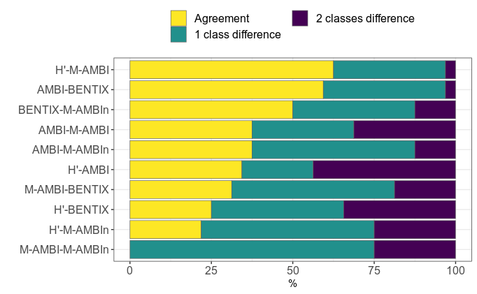

```r
## we'll plot as stacked bar chart with fill colors by level of agreement (diff); we need to put the fill factor in descending order, because ggplot stacks bottom to top.
ind.percent.agreement.zostera <- ind.percent.agreement.zostera %>%
    mutate(diff = factor(diff, levels = rev(0:3))) %>%
    mutate(ind = factor(ind, levels = rev(unique(ind)))) # in reverse order, so that on the plot, they'll come out arranged by highest % perfect agreement (diff = 0)

## plot
(plot.ind.percent.agr.zostera <- ggplot(ind.percent.agreement.zostera,
                                     aes(x = ind, y = percent_agr, fill = diff)) +
        geom_bar(stat = "identity", colour = "grey40", size = 0.25) +
        # very ugly padding hack to increase spacing of legend items:
        scale_fill_viridis(discrete = TRUE, name = "",
                           labels = c(" 2 classes difference  ",
                                      " 1 class difference  ",
                                      " Agreement  ")) +
        labs(x = "", y = "%") +
        coord_flip() +
        guides(fill = guide_legend(reverse = TRUE, nrow = 2, byrow = FALSE)) + # reverse the order of the legend, it gets messed up when putting it on top
        theme(legend.position = "top") +
        text_size(text.x = 12, text.y = 12, legend.text = 12, title.y = 12)
)
```

Nice, there is some pretty high agreement (where there is), and then mostly 1 class difference only.  
Surprising: difference M-AMBI-M-AMBIn - total disagreement. Those old boundaries must really be unsuitable for the seagrass communities..

Save this plot.

```r
ggsave(here(figures.dir, "ind_perc_agreement_zostera.png"),
       dpi = 300, width = 16, height = 15, units = "cm")
```

Check in how many cases the diffences cross the good-moderate border - that would be the one requiring measures to be taken.

```r
## custom function
gm.diff.zostera <- gm_diff(indices.all.norm.zostera, ind.limits)

## fix index names, because I have OCD
(gm.diff.zostera <- gm.diff.zostera %>%
    mutate(contrast = str_replace_all(contrast, pattern = ".EQR", replacement = ""))
)
```

| contrast | gm_diff |
| --- | --- |
| H-AMBI | 0.62500 |
| H-M-AMBI | 0.59375 |
| H-BENTIX | 0.56250 |
| H-M-AMBIn | 0.40625 |
| AMBI-M-AMBI | 0.46875 |
| AMBI-BENTIX | 0.12500 |
| AMBI-M-AMBIn | 0.53125 |
| M-AMBI-BENTIX | 0.53125 |
| M-AMBI-M-AMBIn | 1.00000 |
| BENTIX-M-AMBIn | 0.46875 |

NB this is different than the differences between stations (see plot), because the **normalized EQRs** are used. If the non-normalized (really observed) EQRs are used, the proportion of differences that cross the G/M boundary are smaller.

Well this was an exercise in futility.  
The most surprising result again is M-AMBI-M-AMBIn - 100% of the cases are on opposite sides of the GM boundary. This means that one really, really shouldn’t use M-AMBIn and the old boundaries if one wants something resembling a sensible result.  
The others are more or less as expected, given the previous agreement analyses. The best is AMBI-BENTIX - it happens in only 12% of the cases.

All in all, the soft-bottom zoobenthic indices as they are applied here are really bad in the seagrass. Possible solutions: 1) adapt the boundaries to seagrass-associated fauna - good luck, with the amount of variation observed, and the interference of the natural environmental particularities, see community structure analyses 2) make/adapt a new index, specifically for seagrass fauna 3) drop entirely from assessments - no point; probably sufficient to monitor ecological state of seagrass itself - if it’s good, it’s likely that the associated communities will do perfectly fine. Bonus: those assessments are immensely easier to apply/train people to do.